# lab-03

Ecosystem Science and Sustainability 330

Author

Sara McLaughlin

```r
library(tidyverse)
library(flextable)
library(zoo)
```

##Question 1: #Easy access to historical and real-time environmental data is helpful in expanding our understandng of climate change, natural resources, and public health because it is important to analyze trends over time in order to draw conclusions on these topics and predict future trends. Open data is important because without a plethora of historical data to draw on, these historic and futuristic trends would be a lot more difficult to observe and analyze, and therefore mitigate. When this data becomes unavailable we no longer have baseline data to draw comparisons with where we are at now, which makes it much more difficult to draw causal relationships in these study areas. Furthermore, history is known to repeat itself. If significant historical data is missing, it is more likely that we will repeat the same mistakes and diminish progression.

##Question 2:

```r
data = read.csv('https://raw.githubusercontent.com/nytimes/covid-19-data/master/us-counties.csv')
my.date <- as.Date("2022-02-01")
my.state <- "Colorado"
```

```r
library(dplyr)
data <- data %>% mutate(
  new_cases = cases - lag(cases, n = 1),
  new_deaths = deaths - lag(deaths, n = 1),
) %>% mutate(new_cases = ifelse(is.na(new_cases), 0, new_cases))

colorado_data <- data %>% filter(state == "Colorado") %>% arrange(county, date) %>% group_by(county) %>% ungroup()
```

```r
most_cum_cases <- colorado_data %>% filter(date == my.date) %>% group_by(county) %>% arrange(desc(cases)) %>% head(n = 5) %>%
  select(county, cases) %>%
  rename(County = county, 'Cumulative Cases' = cases)
flextable(most_cum_cases) %>% set_caption("Top 5 Colorado counties with the most cumulative cases on 2022-02-01")
```

| County | Cumulative Cases |
| --- | --- |
| El Paso | 170,673 |
| Denver | 159,022 |
| Arapahoe | 144,255 |
| Adams | 126,768 |
| Jefferson | 113,240 |

```r
most_new_cases <- colorado_data %>% filter(date == my.date) %>% group_by(county) %>% arrange(desc(new_cases)) %>% head(n = 5) %>%
select(county, new_cases) %>%
  rename(County = county, 'New Cases' = new_cases)
flextable(most_new_cases) %>% set_caption("Top 5 Colorado counties with the most new cases on 2022-02-01")
```

| County | New Cases |
| --- | --- |
| El Paso | 155,576 |
| Denver | 153,522 |
| Arapahoe | 140,133 |
| Jefferson | 113,097 |
| Adams | 110,478 |

# Question 3:

```r
pop_data = read.csv('https://www2.census.gov/programs-surveys/popest/datasets/2020-2023/counties/totals/co-est2023-alldata.csv')
pop_data <- pop_data %>% mutate(
  state_code = sprintf("%02d", STATE),
  county_code = sprintf("%03d", COUNTY),
  fips = paste0(state_code, county_code)) %>%
  mutate(fips = sprintf("%05d", as.numeric(fips))) %>%
  filter(county_code != "000")
data <- data %>% mutate(fips = sprintf("%05d", as.numeric(fips)))
selected_data <- pop_data %>% select(contains("NAME"), contains("2021"))
```

```r
glimpse(selected_data)
```

```
Rows: 3,144
Columns: 18
$ STNAME                <chr> "Alabama", "Alabama", "Alabama", "Alabama", "Ala…
$ CTYNAME               <chr> "Autauga County", "Baldwin County", "Barbour Cou…
$ POPESTIMATE2021       <int> 59203, 239439, 24533, 22359, 59079, 10143, 18890…
$ NPOPCHG2021           <int> 288, 6212, -436, 171, -28, -86, -135, -565, -163…
$ BIRTHS2021            <int> 686, 2337, 270, 240, 654, 111, 227, 1250, 392, 2…
$ DEATHS2021            <int> 696, 2948, 390, 325, 875, 160, 297, 1843, 592, 4…
$ NATURALCHG2021        <int> -10, -611, -120, -85, -221, -49, -70, -593, -200…
$ INTERNATIONALMIG2021  <int> 15, 105, 0, 1, 9, 1, 5, 12, 22, 7, 20, 1, 0, -1,…
$ DOMESTICMIG2021       <int> 242, 6972, -313, 254, 141, -42, -75, -70, -6, 28…
$ NETMIG2021            <int> 257, 7077, -313, 255, 150, -41, -70, -58, 16, 29…
$ RESIDUAL2021          <int> 41, -254, -3, 1, 43, 4, 5, 86, 21, 2, 18, 7, 8, …
$ GQESTIMATES2021       <int> 484, 3351, 2248, 1994, 616, 1578, 285, 5407, 856…
$ RBIRTH2021            <dbl> 11.615503, 9.888589, 10.908650, 10.775136, 11.06…
$ RDEATH2021            <dbl> 11.78483, 12.47392, 15.75694, 14.59133, 14.80717…
$ RNATURALCHG2021       <dbl> -0.1693222, -2.5853351, -4.8482890, -3.8161941, …
$ RINTERNATIONALMIG2021 <dbl> 0.25398330, 0.44428836, 0.00000000, 0.04489640, …
$ RDOMESTICMIG2021      <dbl> 4.0975973, 29.5007468, -12.6459537, 11.4036860, …
$ RNETMIG2021           <dbl> 4.3515806, 29.9450352, -12.6459537, 11.4485824, …
```

```r
dim(selected_data)
```

```
[1] 3144   18
```

```r
colnames(selected_data)
```

```
 [1] "STNAME"                "CTYNAME"               "POPESTIMATE2021"
 [4] "NPOPCHG2021"           "BIRTHS2021"            "DEATHS2021"
 [7] "NATURALCHG2021"        "INTERNATIONALMIG2021"  "DOMESTICMIG2021"
[10] "NETMIG2021"            "RESIDUAL2021"          "GQESTIMATES2021"
[13] "RBIRTH2021"            "RDEATH2021"            "RNATURALCHG2021"
[16] "RINTERNATIONALMIG2021" "RDOMESTICMIG2021"      "RNETMIG2021"
```

```r
colorado_range <- selected_data %>% filter(STNAME == "Colorado") %>% pull(POPESTIMATE2021)
colorado_range <- range(colorado_range)
print(colorado_range)
```

```
[1]    741 737287
```

## The range of populations seen in Colorado counties in 2021 extends from 741 to 737,287 people.

```r
library(dplyr)
pop_data <- pop_data %>% mutate(fips = as.character(fips))
data <- data %>% mutate(fips = as.character(fips))
data <- data %>% filter(!is.na(fips))
combined_data <- data %>% inner_join(pop_data, by = "fips") %>%
  mutate(
  per_capita_cum_cases = cases / POPESTIMATE2021,
  per_capita_new_cases = new_cases / POPESTIMATE2021,
  per_capita_new_deaths = new_deaths / POPESTIMATE2021,
)
```

```r
top_cum_cases <- combined_data %>% filter(date == "2021-02-01", STNAME == "Colorado") %>% arrange(desc(per_capita_cum_cases)) %>% select(STNAME, CTYNAME, per_capita_cum_cases) %>% head(n = 5) %>% rename(
  "County" = CTYNAME,
  "State" = STNAME,
  "Cumulative Cases Per Capita" = per_capita_cum_cases
) %>% print()
```

```
     State         County Cumulative Cases Per Capita
1 Colorado Crowley County                   0.3166521
2 Colorado    Bent County                   0.2416183
3 Colorado Lincoln County                   0.1746757
4 Colorado   Logan County                   0.1727602
5 Colorado  Pitkin County                   0.1057853
```

```r
top_new_cases <- combined_data %>%
  filter(date == "2021-02-01", state == "Colorado") %>%
   select(state, county, per_capita_new_cases) %>%
  slice_max(order_by = per_capita_new_cases, n = 5) %>%
  rename(
  "County" = county,
  "State" = state,
  "New Cases Per Capita" = per_capita_new_cases
) %>% print()
```

```
     State  County New Cases Per Capita
1 Colorado Crowley           0.28561465
2 Colorado    Bent           0.19217082
3 Colorado   Logan           0.12724936
4 Colorado  Pitkin           0.08703928
5 Colorado Fremont           0.08160530
```

```r
flextable(top_cum_cases) %>% set_caption("Top 5 counties in Colorado with the most cumulative cases per capita on 2021-02-01")
```

| State | County | Cumulative Cases Per Capita |
| --- | --- | --- |
| Colorado | Crowley County | 0.3166521 |
| Colorado | Bent County | 0.2416183 |
| Colorado | Lincoln County | 0.1746757 |
| Colorado | Logan County | 0.1727602 |
| Colorado | Pitkin County | 0.1057853 |

```r
flextable(top_new_cases) %>% set_caption("Top 5 counties in Colorado with the most new cases per capita on 2021-02-01")
```

| State | County | New Cases Per Capita |
| --- | --- | --- |
| Colorado | Crowley | 0.28561465 |
| Colorado | Bent | 0.19217082 |
| Colorado | Logan | 0.12724936 |
| Colorado | Pitkin | 0.08703928 |
| Colorado | Fremont | 0.08160530 |

#4: ## !!! I know that my outputs for questions 4, 5, and 6 are inaccurate. I attended about 7 hours worth of office hours and asked questions for the entirety of my lab section, but nothing solved my issues and nobody was able to help me figure it out. I spent a crazy amount of hours on the lab overall and decided to just submit what I have for the sake of my mental health and sanity. I’m sorry for this, if you have any tips for how to fix my problems I would greatly appreciate it. ##Here are the issues I know my work has: Question 4 shows counties with cases per 100k people much greater than 100,000, which would not make sense. Question 5 shows some counties that make up a percentage larger than 100% and the counties do not all add to 100, which does not make sense. Question 6 shows two of the states having negative case values, which does not make sense.

```r
library(dplyr)
top_list <- combined_data %>% filter(date >= my.date - 14, state == "Colorado") %>%
  group_by(county) %>%
  reframe(
    total_new_cases = sum(new_cases, na.rm = TRUE),
    cases_per_100k = (total_new_cases / POPESTIMATE2021) * 100000
  ) %>%
  distinct() %>%
  slice_max(order_by = cases_per_100k, n = 5)
top_list <- as.data.frame(top_list)
print(top_list)
```

```
      county total_new_cases cases_per_100k
1    Crowley          288493        5030392
2     Pitkin          629048        3628356
3       Bent          189836        3555647
4     Summit         1061203        3423456
5 San Miguel          234662        2904233
```

```r
all_list <- combined_data %>% filter(date >= my.date - 14, state == "Colorado") %>%
  group_by(county) %>%
  reframe(
    total_new_cases = sum(new_cases, na.rm = TRUE),
    cases_per_100k = (total_new_cases / POPESTIMATE2021)* 100000
  ) %>%
  distinct() %>%
  filter(cases_per_100k > 100)
all_list <- as.data.frame(all_list)
print(all_list)
```

```
        county total_new_cases cases_per_100k
1        Adams        13235423      2528044.1
2     Arapahoe        16869122      2568165.3
3         Bent          189836      3555647.1
4      Boulder         6898388      2109057.0
5  Clear Creek          138644      1466046.3
6      Conejos           19348       255183.3
7      Crowley          288493      5030392.3
8        Delta          610642      1945215.3
9       Denver        18558732      2608516.2
10     Douglas         8852373      2393937.3
11     El Paso        19005325      2577737.7
12     Fremont         1144789      2325058.4
13       Grand          290861      1834969.4
14    Huerfano          147220      2123161.2
```

[output cut: 17 more lines]

## 31 counties meet the watch list condition: there are more than 100 new cases per 100,000 residents over the past 14 days in these counties.

#5:

```r
library(dplyr)
library(ggplot2)
covid_2021 <- data %>%
  filter(state == "Colorado", date >= "2021-02-01", date <= "2021-12-31") %>%
  group_by(fips)

new_pop_data <- pop_data %>%
  filter(county_code != "000") %>%
  select(fips, CTYNAME, DEATHS2021)
merged_2021_data <- covid_2021 %>%
  group_by(county) %>%
  left_join(new_pop_data, by = "fips") %>%
  mutate(
    covid_death_percent = (deaths / DEATHS2021) * 100
  ) %>%
  select(CTYNAME, covid_death_percent) %>%
  filter(covid_death_percent >= 20)
merged_2021_data <- as.data.frame(merged_2021_data)
print(merged_2021_data)
```

```
         county           CTYNAME covid_death_percent
1          Bent       Bent County            25.97403
2      Cheyenne   Cheyenne County            20.83333
3       Crowley    Crowley County            21.53846
4        Morgan     Morgan County            28.70968
5          Bent       Bent County            25.97403
6      Cheyenne   Cheyenne County            20.83333
7       Crowley    Crowley County            21.53846
8        Morgan     Morgan County            28.70968
9          Bent       Bent County            25.97403
10     Cheyenne   Cheyenne County            20.83333
11      Crowley    Crowley County            21.53846
12       Morgan     Morgan County            28.70968
13         Bent       Bent County            25.97403
14     Cheyenne   Cheyenne County            20.83333
```

[output cut: 3589 more lines]

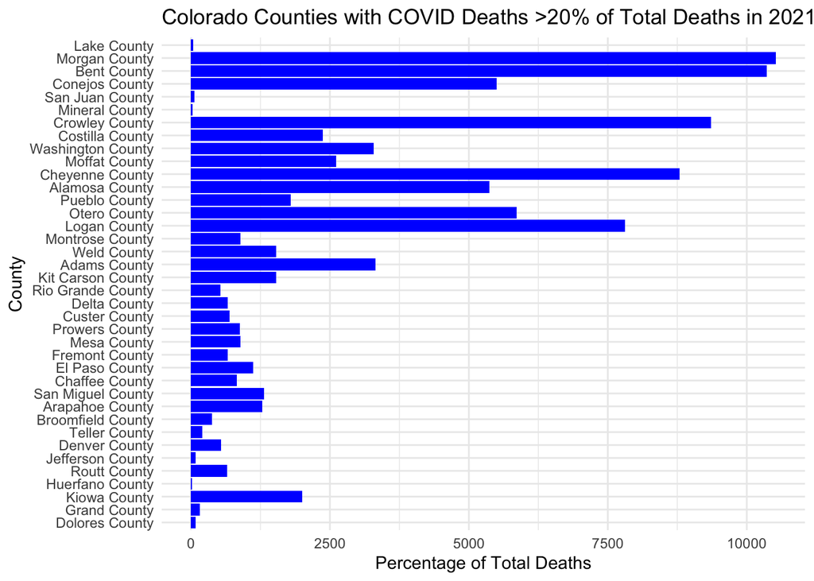

```r
ggplot(merged_2021_data, aes(x = reorder(CTYNAME, covid_death_percent), y = covid_death_percent)) +
  geom_col(fill = "blue") +
  coord_flip() +
  labs(
    title = "Colorado Counties with COVID Deaths >20% of Total Deaths in 2021",
    x = "County",
    y = "Percentage of Total Deaths"
  ) +
  theme_minimal()
```

#6:

[output not shown]

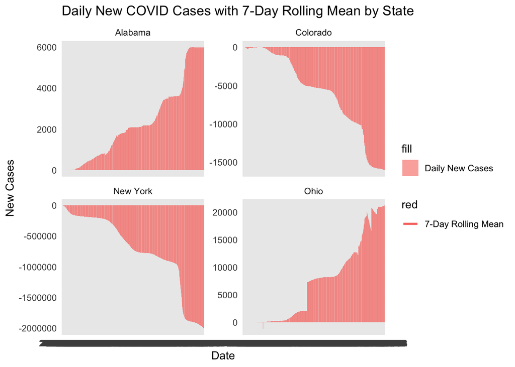

```r
daily_new_cases <- combined_data %>%
  filter(state %in% c("New York", "Colorado", "Alabama", "Ohio")) %>%
  group_by(state, date) %>%
  summarize(total_new_cases = sum(new_cases, na.rm = TRUE)) %>%
  group_by(state) %>%
  mutate(
    rolling_mean = zoo::rollmean(total_new_cases, 7, fill = NA, align = "right", na.pad = FALSE)
  ) %>%
  filter(!is.na(rolling_mean))
library(ggplot2)
ggplot(daily_new_cases, aes(x = date)) +
  geom_col(aes(y = total_new_cases, fill = "Daily New Cases"), alpha = 0.6) +
  geom_line(aes(y = rolling_mean, color = "7-Day Rolling Mean"), size = 1) +
  facet_wrap(~ state, scales = "free_y") +
  labs(
    title = "Daily New COVID Cases with 7-Day Rolling Mean by State",
    x = "Date",
    y = "New Cases",
    color = "red"
  ) +
  theme_minimal()
```